# Trabajo Práctico 1

Ignacio Garcia Pizales, Mara Mantegazza y María Carolina Rojas

18 de Octubre

### Imports de paquetes

```r
require(dplyr)
```

```r
require(rvest)
```

```r
require(xml2)
```

```r
require(geosphere)
```

```r
require(lubridate)
```

```r
require(leaflet)
```

```r
require(tibble)
```

```r
require(ggplot2)
```

```r
require(RColorBrewer)
```

```r
require(readr)
```

```r
library(stringr)
library(stringi)
```

### Preprocesamiento

#### Archivos csv Vuelos

```r
## carga del dataset de vuelos del 2021
viajes = read_csv2("202109-informe-ministerio.csv")
```

```r
##  Renombramos las variables del dataset para una mejor organizacion
viajes <- viajes %>%
              rename(Hora = `Hora UTC`,
                     Clase = `Clase de Vuelo (todos los vuelos)`,
                     Clasificación = `Clasificación Vuelo`,
                     Tipo = `Tipo de Movimiento`,
                     Destino = `Origen / Destino`,
                     Aerolinea = `Aerolinea Nombre`,
                     Calidad = `Calidad dato`)


## El dataset posee informacion de fecha y hora de cada uno de los vuelos, ésta información esta dada en formato string la fecha y en formato time la hora. Para poder utilizar y operar con esta esta información y es conveniente unifircar el formato y transformarla a un formato de fecha-hora.
viajes$Fecha_Hora = paste(viajes$Fecha, viajes$Hora)
viajes$Fecha_Hora = dmy_hms(viajes$Fecha_Hora)
viajes <- subset(viajes, select = -c(Fecha, Hora, Calidad))
viajes = add_column(viajes, id = 1:nrow(viajes), .before = 1)
```

| id | Clase | Clasificación | Tipo | Aeropuerto | Destino | Aerolinea | Aeronave | Pasajeros | Fecha_Hora |
| --- | --- | --- | --- | --- | --- | --- | --- | --- | --- |
| 145081 | Vuelo Privado con Matrícula Nacional | Dom | Despegue | FDO | DRY | AEROVIDA S.A. | CE-560 | 0 | 2021-07-09 22:12:00 |
| 218496 | Vuelo Privado con Matrícula Nacional | Inter | Despegue | FDO | SUMU | 0 | BE-C-90 | 2 | 2021-09-29 20:17:00 |
| 183389 | No Regular | Dom | Despegue | FDO | DOZ | SOCORRO MEDICO PRIVADO (VITTAL) | CE-550 | 0 | 2021-08-21 06:01:00 |
| 175342 | Regular | Dom | Aterrizaje | JUJ | AER | FB LÍNEAS AÉREAS - FLYBONDI | BO-737-86J | 90 | 2021-08-12 23:15:00 |
| 59451 | Vuelo Oficial Nacional | Dom | Aterrizaje | RTA | RTA | 0 | 0 | 0 | 2021-03-15 17:01:00 |
| 79973 | Regular | Inter | Aterrizaje | EZE | SUMU | LUFTHANSA CARGO AG. | 0 | 0 | 2021-04-10 22:30:00 |

```r
## carga del dataset de vuelos del 2020
viajes_2020 = read.csv2("aterrizajes-y-despegues-registrados-por-eana-2020.csv", sep = ";")

##  Renombramos las variables del dataset para una mejor organizacion
viajes_2020 <- viajes_2020 %>%
              rename(Clase = `Clase.de.Vuelo`,
                     Clasificación = `Clasificación.Vuelo`,
                     Tipo = `Tipo.de.Movimiento`,
                     Destino = `Destino.OACI`,
                     Aerolinea = `Aerolinea.Nombre`,
                     Origen = `Origen.OACI`)

## El dataset posee informacion de fecha en formato string la fecha. Para poder utilizar y operar con esta esta información y es conveniente  transformarla a un formato de fecha.
viajes_2020$Fecha <- dmy(viajes_2020$Fecha)

## carga del dataset de vuelos del 2019
viajes_2019 = read.csv2("aterrizajes-y-despegues-registrados-por-eana-2019.csv", sep = ";")

##  Renombramos las variables del dataset para una mejor organizacion
viajes_2019 <- viajes_2019 %>%
              rename(Clase = `Clase.de.Vuelo`,
                     Clasificación = `Clasificación.Vuelo`,
                     Tipo = `Tipo.de.Movimiento`,
                     Destino = `Destino.OACI`,
                     Aerolinea = `Aerolinea.Nombre`,
                     Origen = `Origen.OACI`)

## El dataset posee informacion de fecha en formato string la fecha. Para poder utilizar y operar con esta esta información y es conveniente  transformarla a un formato de fecha.
viajes_2019$Fecha <- dmy(viajes_2019$Fecha)
```

## EXPLORANDO EL DATASET DE VUELOS DEL AÑO 2021

El objetivo de explorar los datos previo a cualquier analisis es conocer el dataset y entender que tipo de variables se estan utilizando, en que formatos están. A partir de esto, poder plantearse objetivos y filtrar el dataset original quedándose con la información que vaya a utilizarse.

| id | Clase | Clasificación | Tipo | Aeropuerto | Destino | Aerolinea | Aeronave | Pasajeros | Fecha_Hora |
| --- | --- | --- | --- | --- | --- | --- | --- | --- | --- |
| 1 | Vuelo Privado con Matrícula Nacional | Dom | Despegue | PAR | ROS | 0 | PA-PA-28-181 | 0 | 2021-01-01 00:02:00 |
| 2 | Regular | Dom | Aterrizaje | EZE | GRA | AEROLINEAS ARGENTINAS SA | BO-B737-8MB | 70 | 2021-01-01 00:24:00 |
| 3 | Regular | Dom | Aterrizaje | EZE | ECA | AEROLINEAS ARGENTINAS SA | BO-737-800 | 70 | 2021-01-01 00:26:00 |
| 4 | Regular | Dom | Aterrizaje | EZE | SAL | AEROLINEAS ARGENTINAS SA | BO-B-737-76N | 12 | 2021-01-01 00:29:00 |
| 5 | Regular | Dom | Aterrizaje | EZE | TUC | AEROLINEAS ARGENTINAS SA | EMB-ERJ190100IGW | 26 | 2021-01-01 00:37:00 |
| 6 | Regular | Inter | Aterrizaje | EZE | SBGR | TURK HAVA YOLLARI (TURKISH AIRLINES CO.) | 0 | 62 | 2021-01-01 00:59:00 |

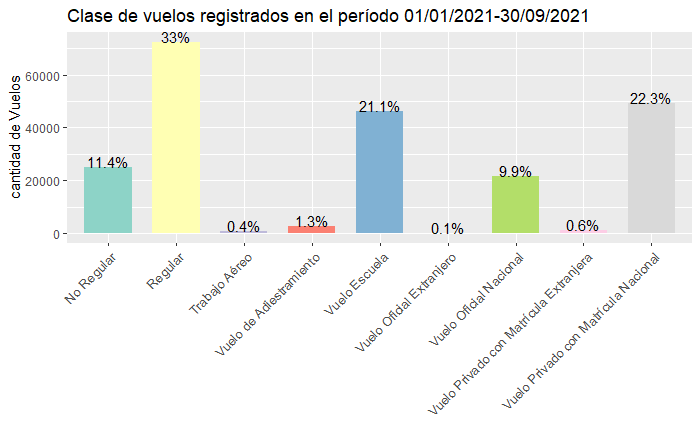

```r
n_clase <- viajes %>%
            group_by(Clase) %>%
            summarise(n = n()) %>%
            mutate(porcentaje = n/sum(n)*100)

coul <- brewer.pal(9, "Set3")
g <- ggplot(data=n_clase, aes(x=Clase, y=n)) +
      geom_bar(stat="identity", width = 0.7, fill = coul)+
      ggtitle("Clase de vuelos registrados en el período 01/01/2021-30/09/2021") +
      xlab(element_blank()) +
      ylab("cantidad de Vuelos") +
      geom_text(aes(label=paste0(round(porcentaje,1),"%")),color="black",vjust=0)
g+theme(axis.text.x=element_text(size=10, angle = 45, vjust = 1, hjust=1))
```

```r
rm(n_clase, coul)
```

```r
n_clase_aerolinea <- viajes %>%
                      group_by(Clase, Aerolinea) %>%
                      summarise(n = n()) %>%
                      mutate(porcentaje = n/sum(n)*100)
```

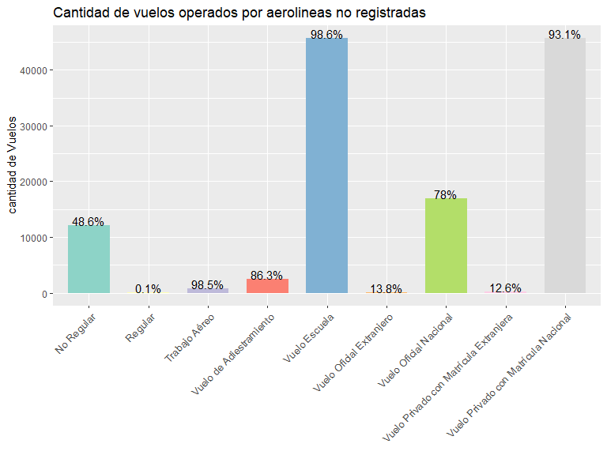

```r
aerolinea_no_registrada <- subset(n_clase_aerolinea, Aerolinea == 0)

coul <- brewer.pal(9, "Set3")
g <- ggplot(data=aerolinea_no_registrada, aes(x=Clase, y=n)) +
     ggtitle("Cantidad de vuelos operados por aerolineas no registradas") +
      geom_bar(stat="identity", width = 0.7, fill = coul)+
      xlab(element_blank()) +
      ylab("cantidad de Vuelos")+
      geom_text(aes(label=paste0(round(porcentaje,1),"%")),color="black",vjust=0)

g+theme(axis.text.x=element_text(size=10, angle = 45, vjust = 1, hjust=1))
```

```r
rm(aerolinea_no_registrada, n_clase_aerolinea, coul)
```

Nuestros objetivos principales son: - Poder establecer las conexciones entre los aeropuertos - Identificar los aeropuertos más importantes del país en cuánto a la cantidad de despegues y aterrizajes. - Establecer la temporalidad y recurrencia de los vuelos, fueron estos afectados por las medidas tomadas durante la pandemia de COVID-19?

A partir de la exploración inicial del dataframe, decidimos evaluar y analizar solamente los vuelos que están clasificados como clase Regular. Si bien éstos representan el 33% de los datos, nuestros interés está puesto sobre los vuelos de cabojate regulares operados por aerolineas registradas y decidimos filtrar los vuelos de entrenamiento, privados, internacionales y no regulares.

### Separo en aterrizajes y despegues

```r
aterrizajes <- viajes %>% filter(Tipo == "Aterrizaje" & Clase == "Regular" & Clasificación == "Dom")
despegues <- viajes %>% filter(Tipo == "Despegue" & Clase == "Regular" & Clasificación == "Dom")
aterrizajes <- subset(aterrizajes, select = -c(Clase, Clasificación, Tipo))
despegues <- subset(despegues, select = -c(Clase, Clasificación, Tipo))
viajes_organizado <- despegues %>%
                      inner_join(aterrizajes, by =
                               c("Destino" = "Aeropuerto",
                                 "Aeropuerto" = "Destino",
                                 "Aeronave" = "Aeronave",
                                 "Aerolinea" = "Aerolinea",
                                 "Pasajeros" = "Pasajeros"),
                               suffix = c("_despegue", "_aterrizaje"))
viajes_organizado$dif_horaria = difftime(viajes_organizado$Fecha_Hora_aterrizaje, viajes_organizado$Fecha_Hora_despegue, units = "hours")
viajes_organizado$dif_horaria = as.numeric(viajes_organizado$dif_horaria)
viajes_organizado <- viajes_organizado %>% filter(dif_horaria <= 10 & dif_horaria >= 0)
viajes_organizado = viajes_organizado %>% distinct(id_despegue, .keep_all = TRUE)
viajes_organizado = viajes_organizado %>% distinct(id_aterrizaje, .keep_all = TRUE)
viajes_organizado <- viajes_organizado %>% filter(Aeropuerto != Destino)
rm(viajes, aterrizajes, despegues)
head(viajes_organizado, 100)
```

| id_despegue | Aeropuerto | Destino | Aerolinea | Aeronave | Pasajeros | Fecha_Hora_despegue | id_aterrizaje | Fecha_Hora_aterrizaje | dif_horaria |
| --- | --- | --- | --- | --- | --- | --- | --- | --- | --- |
| 16 | EZE | ECA | AEROLINEAS ARGENTINAS SA | BO-B737-800 | 35 | 2021-01-01 07:09:00 | 30 | 2021-01-01 10:11:00 | 3.0333333 |
| 17 | EZE | JUJ | AEROLINEAS ARGENTINAS SA | EMB-ERJ190100IGW | 46 | 2021-01-01 08:10:00 | 29 | 2021-01-01 10:00:00 | 1.8333333 |
| 20 | EZE | USU | AEROLINEAS ARGENTINAS SA | BO-B737-8MB | 74 | 2021-01-01 08:35:00 | 53 | 2021-01-01 12:05:00 | 3.5000000 |
| 25 | EZE | USU | AEROLINEAS ARGENTINAS SA | BO-737-8SH | 71 | 2021-01-01 09:11:00 | 66 | 2021-01-01 12:39:00 | 3.4666667 |
| 32 | EZE | BAR | AEROLINEAS ARGENTINAS SA | BO-B737-81D | 80 | 2021-01-01 10:16:00 | 58 | 2021-01-01 12:14:00 | 1.9666667 |
| 33 | EZE | CRV | AEROLINEAS ARGENTINAS SA | BO-737-8BK | 28 | 2021-01-01 10:21:00 | 61 | 2021-01-01 12:30:00 | 2.1500000 |
| 36 | EZE | TUC | AEROLINEAS ARGENTINAS SA | EMB-ERJ190100IGW | 43 | 2021-01-01 10:34:00 | 55 | 2021-01-01 12:07:00 | 1.5500000 |
| 38 | EZE | DOZ | AEROLINEAS ARGENTINAS SA | BO-737-800 | 67 | 2021-01-01 10:39:00 | 56 | 2021-01-01 12:12:00 | 1.5500000 |
| 39 | EZE | SAL | AEROLINEAS ARGENTINAS SA | BO-B-737-76N | 59 | 2021-01-01 10:44:00 | 43 | 2021-01-01 11:06:00 | 0.3666667 |
| 46 | EZE | CBA | AEROLINEAS ARGENTINAS SA | BO-B737-8LP | 66 | 2021-01-01 11:29:00 | 63 | 2021-01-01 12:31:00 | 1.0333333 |

[output cut: 90 more lines]

```r
viajes_organizado$dia_semana_despegue = wday(viajes_organizado$Fecha_Hora_despegue, label = TRUE, abbr = FALSE)
viajes_organizado$dia_semana_aterrizaje = wday(viajes_organizado$Fecha_Hora_aterrizaje, label = TRUE, abbr = FALSE)
```

| id_despegue | Aeropuerto | Destino | Aerolinea | Aeronave | Pasajeros | Fecha_Hora_despegue | id_aterrizaje | Fecha_Hora_aterrizaje | dif_horaria | dia_semana_despegue | dia_semana_aterrizaje |
| --- | --- | --- | --- | --- | --- | --- | --- | --- | --- | --- | --- |
| 208992 | DOZ | AER | JETSMART AIRLINES S.A. | AIB-A320-232 | 76 | 2021-09-18 00:11:00 | 209036 | 2021-09-18 01:29:00 | 1.3000000 | sábado | sábado |
| 149624 | BAR | AER | AEROLINEAS ARGENTINAS SA | EMB-ERJ190100IGW | 14 | 2021-07-16 00:40:00 | 149661 | 2021-07-16 02:32:00 | 1.8666667 | viernes | viernes |
| 28654 | CBA | EZE | AEROLINEAS ARGENTINAS SA | BO-B737-8MB | 75 | 2021-02-07 21:27:00 | 28714 | 2021-02-07 22:26:00 | 0.9833333 | domingo | domingo |
| 120535 | SIS | AER | AEROLINEAS ARGENTINAS SA | EMB-ERJ190100IGW | 0 | 2021-06-04 22:58:00 | 120552 | 2021-06-05 00:11:00 | 1.2166667 | viernes | sábado |
| 25618 | SAL | EZE | AEROLINEAS ARGENTINAS SA | EMB-ERJ190100IGW | 45 | 2021-02-04 14:47:00 | 25762 | 2021-02-04 16:38:00 | 1.8500000 | jueves | jueves |
| 48229 | EZE | DOZ | AEROLINEAS ARGENTINAS SA | BO-B-737-81D | 79 | 2021-03-02 19:45:00 | 48302 | 2021-03-02 21:11:00 | 1.4333333 | martes | martes |
| 40549 | EZE | ROS | AEROLINEAS ARGENTINAS SA | EMB-ERJ190100IGW | 33 | 2021-02-21 23:32:00 | 40570 | 2021-02-22 00:13:00 | 0.6833333 | domingo | lunes |
| 179168 | CRR | AER | JETSMART AIRLINES S.A. | AIB-A320-232 | 41 | 2021-08-16 20:30:00 | 179196 | 2021-08-16 20:50:00 | 0.3333333 | lunes | lunes |
| 153890 | CBA | AER | AEROLINEAS ARGENTINAS SA | EMB-ERJ190100IGW | 30 | 2021-07-20 17:34:00 | 153970 | 2021-07-20 18:36:00 | 1.0333333 | martes | martes |
| 196159 | BAR | AER | AEROLINEAS ARGENTINAS SA | BO-B737-800 | 88 | 2021-09-03 17:47:00 | 196309 | 2021-09-03 19:32:00 | 1.7500000 | viernes | viernes |

[output cut: 90 more lines]

```r
viajes_organizado_2019 <- viajes_2019 %>% filter(Clasificación == "Cabotaje     " &
                                                  Clase == "Regular                             ")

viajes_organizado_2020 <- viajes_2020 %>% filter(Clasificación == c("Cabotaje     ", "Cabojate") &
                                                  Clase == c("Regular                             ", "Regular"))
```

### Aeropuertos

```r
aeropuertos = read_csv("sna_abril_2021_fixed_encoding (1).csv")
```

```r
aeropuertos <- subset(aeropuertos, select = c(fna, nam, ana, x, y))
aeropuertos = aeropuertos %>% rename(Nombre = fna,
                                     Ciudad = nam,
                                     id = ana,
                                     lon = x,
                                     lat = y)
head(aeropuertos)
```

| Nombre | Ciudad | id | lon | lat |
| --- | --- | --- | --- | --- |
| Aeropuerto de El Calafate Comandante Armando Tola | El Calafate | ECA | -72.05305 | -50.28035 |
| Aeropuerto de Ushuaia Malvinas Argentinas | Ushuaia | USU | -68.30810 | -54.84359 |
| Aeropuerto de Río Gallegos Piloto Civil Norberto Fernández | Rio Gallegos | GAL | -69.30792 | -51.60895 |
| Aeropuerto de Rio Grande Gob. Ramón Trejo Noel | Río Grande | GRA | -67.75308 | -53.77784 |
| Aeropuerto de Esquel Brigadier General Antonio Parodi | Esquel | ESQ | -71.13665 | -42.90471 |
| Aeropuerto de San Carlos de Bariloche Teniente Luis Candelaria | San Carlos de Bariloche | BAR | -71.15931 | -41.15032 |

### Información y gráficos

```r
n_occur_aeropuerto <- viajes_organizado %>%
            group_by(Aeropuerto) %>%
            summarise(n = n())
n_occur_aeropuerto = n_occur_aeropuerto %>% left_join(aeropuertos, by = c("Aeropuerto" = "id"))
n_occur <- viajes_organizado %>%
            group_by(Aeropuerto, Destino) %>% #este groupby es para el summarize
            summarise(n = n()) %>%
            select(c(1,2))
n_occur <- n_occur %>%
            inner_join(n_occur_aeropuerto, by = "Aeropuerto") %>%
            rename(lon.x = lon, lat.x = lat)
n_occur <- n_occur[,-(3:5)]
n_occur <- n_occur[,c(1,3,4,2)]
n_occur <- n_occur %>%
            inner_join(n_occur_aeropuerto, by = c("Destino" = "Aeropuerto")) %>%
            rename(lon.y = lon, lat.y = lat)
n_occur <- n_occur[,-(5:7)]
n_occur$distancia = distHaversine(n_occur[,2:3], n_occur[,5:6])
head(n_occur)
```

| Aeropuerto | lon.x | lat.x | Destino | lon.y | lat.y | distancia |
| --- | --- | --- | --- | --- | --- | --- |
| AER | -58.41343 | -34.56055 | BAR | -71.15931 | -41.15032 | 1336901.4 |
| AER | -58.41343 | -34.56055 | BCA | -62.15380 | -38.72368 | 571179.3 |
| AER | -58.41343 | -34.56055 | CAT | -65.75271 | -28.59432 | 961485.0 |
| AER | -58.41343 | -34.56055 | CBA | -64.20820 | -31.31558 | 650637.8 |
| AER | -58.41343 | -34.56055 | CHP | -71.14068 | -40.07670 | 1281402.3 |
| AER | -58.41343 | -34.56055 | CRR | -58.76200 | -27.44818 | 792442.6 |

```r
rm(aeropuertos)
```

Los aeropuertos mas lejanos entre sí

```r
n_occur <-n_occur[order(-n_occur$distancia),]
head(n_occur[,c(1,4,7)], 1)
```

| Aeropuerto | Destino | distancia |
| --- | --- | --- |
| CRV | JUJ | 2391142 |

```r
coul <- brewer.pal(3, "Set1")
m <- leaflet()%>%
  addTiles() %>%
  addCircleMarkers(data = n_occur_aeropuerto,
                   lat = ~lat, lng = ~lon,
                   radius = ~n/max(n)*10,
                   color = coul,
                   popup = paste0("<b>Aeropuerto: </b>", n_occur_aeropuerto$Aeropuerto,
                                  "<br>", "<b>lat: <b>", n_occur_aeropuerto$lat,
                                  "<br>", "<b>lon: <b>", n_occur_aeropuerto$lon))
for (i in 1:nrow(n_occur)) {
  m <-m %>%
    addPolylines(lat = c(n_occur[i,]$lat.x, n_occur[i,]$lat.y),
                lng = c(n_occur[i,]$lon.x, n_occur[i,]$lon.y),
                weight = 0.3)
}
m <-m %>%
  addPopups(data = n_occur, lat =  -34.50, lng = -58.70, "Hace click en un aeropuerto para ver mas información",
                      options = popupOptions(minWidth = 3, closeOnClick = TRUE, closeButton = TRUE))

m
```

[interactive chart not shown]

```r
rm(m, coul)
```

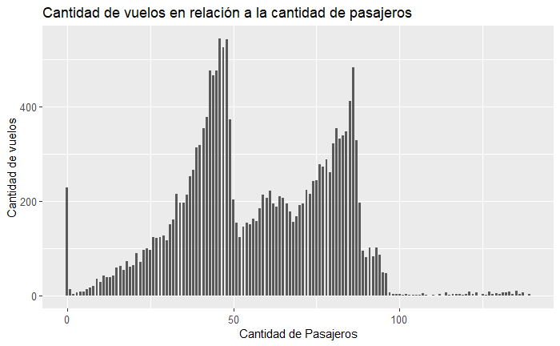

```r
n_pasajeros <- viajes_organizado %>%
  group_by(Pasajeros) %>%
  summarise(n = n())

g <- ggplot(data=n_pasajeros, aes(x=Pasajeros, y=n)) +
  ggtitle("Cantidad de vuelos en relación a la cantidad de pasajeros") +
  geom_bar(stat="identity", width = 0.7) +
  xlab("Cantidad de Pasajeros") +
  ylab("Cantidad de vuelos")
  theme_light()
g+theme(axis.text=element_text(size=10))
```

```r
rm(g)
```

[figure not shown]

```r
n_occur <- viajes_organizado %>%
            group_by(dia_semana_despegue) %>%
            summarise(n = n()/52)

coul <- brewer.pal(7, "Set2")
promedio = mean(n_occur$n)
ggplot(data=n_occur, aes(x=dia_semana_despegue, y=n)) +
  ggtitle("Promedio de despegues diarios") +
  geom_bar(stat="identity", width = 0.7, fill = coul) +
  geom_hline(yintercept = promedio, lwd = 1.3, col ="red") +
  xlab(element_blank()) +
  ylab("cantidad de vuelos") +
  theme_light()
```

```r
rm(promedio, n_occur, coul)
```

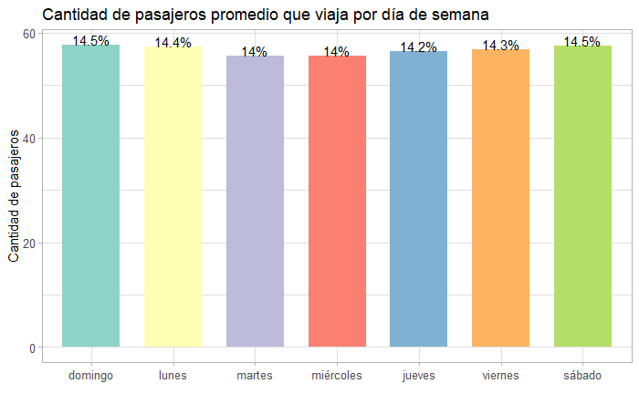

```r
n_pasajeros_dias <- viajes_organizado %>%
                group_by(dia_semana_despegue) %>%
                summarise(Pasajeros_dias = mean(Pasajeros)) %>%
                mutate(porcentaje = Pasajeros_dias/sum(Pasajeros_dias)*100)

coul <-brewer.pal(7, "Set3")

g <- ggplot(data=n_pasajeros_dias, aes(x=dia_semana_despegue, y=Pasajeros_dias)) +
  ggtitle("Cantidad de pasajeros promedio que viaja por día de semana") +
  geom_bar(stat="identity", width = 0.7, fill = coul) +
  xlab(element_blank()) +
  ylab("Cantidad de pasajeros") +
  geom_text(aes(label=paste0(round(porcentaje,1),"%")),color="black",vjust=0) +
  theme_light()

g+theme(axis.text=element_text(size=10))
```

```r
rm(n_pasajeros_dias, coul)
```

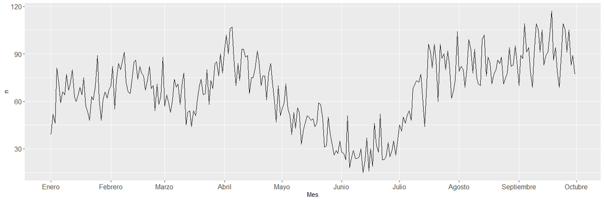

```r
n_diarios <- viajes_organizado %>%
              group_by(fecha = as.Date(Fecha_Hora_despegue))  %>%
              summarise(n = n())

g <- ggplot(data = n_diarios, aes(x = fecha, y =n))+
     geom_line() +
     scale_x_date(name = "Mes", date_breaks = "1 month", minor_breaks = NULL, labels = function(x) stri_trans_totitle(format(x, "%B")))
g+theme(axis.text=element_text(size=12))
```

```r
rm(n_diarios)
```

Para ver los efectos de la pandemia en la cantidad de vuelos de cabotaje vamos a incorporar los datasert de vuelos del 2019 y 2020.

```r
viajes_organizado_2019_despegues <- viajes_organizado_2019 %>%
                                    filter(Tipo == "Despegue  ")  %>%
                                    subset(select = c(Fecha, Aerolinea, Aeronave)) %>%
                                    rename(Fecha_Hora_despegue = Fecha)

viajes_organizado_2020_despegues <- viajes_organizado_2020 %>%
                                    filter(Tipo == "Despegue  ")  %>%
                                    subset(select = c(Fecha, Aerolinea, Aeronave)) %>%
                                    rename(Fecha_Hora_despegue = Fecha)

viajes_completo <- subset(viajes_organizado, select = c(Fecha_Hora_despegue, Aerolinea, Aeronave)) %>%
                    union_all(viajes_organizado_2019_despegues) %>%
                    union_all(viajes_organizado_2020_despegues)

viajes_completo[order(as.Date(viajes_completo$Fecha_Hora_despegue, format="%d/%m/%Y")),]
```

| Fecha_Hora_despegue | Aerolinea | Aeronave |
| --- | --- | --- |
| 2019-01-10 | Austral Líneas Aéreas | EMBRAER E-190 |
| 2019-01-10 | Austral Líneas Aéreas | EMBRAER E-190 |
| 2019-01-10 | Austral Líneas Aéreas | EMBRAER E-190 |
| 2019-01-10 | Aerolíneas Argentinas | BOEING B-737 |
| 2019-01-10 | Austral Líneas Aéreas | EMBRAER E-190 |
| 2019-01-10 | LATAM Argentina | AIRBUS A-320 |
| 2019-01-10 | Aerolíneas Argentinas | BOEING B-737 |
| 2019-01-10 | Aerolíneas Argentinas | BOEING B-737 |
| 2019-01-10 | Aerolíneas Argentinas | BOEING B-737 |
| 2019-01-10 | Austral Líneas Aéreas | EMBRAER E-190 |

[output cut: 990 more lines]

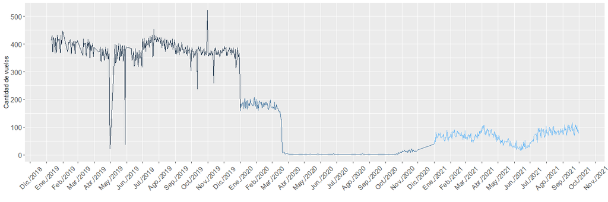

```r
n_diarios_completo <- viajes_completo %>%
              group_by(fecha = as.Date(Fecha_Hora_despegue))  %>%
              summarise(n = n())

g <- ggplot(data = n_diarios_completo, aes(x = fecha, y = n, color = year(fecha))) +
     geom_line() +
     scale_x_date(name = "", date_breaks = "1 month", minor_breaks = NULL, labels = function(x) stri_trans_totitle(format(x, "%b/%Y"))) +
     ylab('Cantidad de vuelos')
g+theme(axis.text.x=element_text(size=12, angle = 45, vjust = .5),
        axis.text.y = element_text(size = 12),
        legend.position="none")
```

```r
rm(g, n_diarios_completo)
```